# Artificial Neural Networks in R

Louis Frayser

2020-03-26

This is an R notebook notebook implementation of a [Ann & Percy](https://github.com/louis-frayser/Ann-and-Percy#create-a-simple-neural-network-in-python-from-scratch) a series of exercises of my coding a single-layer perceptron dubbed “Percy”[^1], plus for the fist time I study a double-layer one called Ann[^2]. In previous exercises I tested various compilers and interpreters for performance and ease of use. In this notebook, I’ll explain the workings of these perceptrons and the how the code works in R.

## One and Two-Layer Perceptrons

Taking a look at two perceptrons, a most simple one, and one with a hidden layer.

### Terminology

Some descriptions*

| Term | Explanation |
| --- | --- |
| Input(s) | The training inputs, or the actual input data(after training) |
| Bias | A special input designed to skew the others |
| weights | Individual adjust for each input |
| network inputs | Inputs with the weights (and bias if any) applied |
| summer | An adder of weighted inputs and the bias |
| transfer function | Also called an activation function. Produces output matched for the next stage |
| neuron output | output of the transfer function |

*[details](https://hagan.okstate.edu/nnd.html)

### Percy the Single-Layer Perceptron

The perceptron is presented with sample input and corresponding output datum. The duty of the perceptron is to produce analogous output given other similar input.

The perceptron accomplishes this by producing an out put comparing its’ output to the the expected one , then adapting. Adaption is accomplished by adjusting the sensitivity he inputs the the input data.

The perceptron is presented with sample input and corresponding output datum. In this case, 4 inputs with corresponding outputs, in the form and input matrix and an output matrix. It this was the perceptron is show by example what to do. It is up to the perceptron to produce analogous output for similar input, even the the input isn’t exactly a sample that it’s trained on.

The training inputs are applied to the input layer in this case. The training is applied biased by separate random weights on each input.

```r
input_layer <- training_inputs <-
  matrix(c(0,0,1, 1,1,1,  1,0,1, 0,1,1), 4, 3, byrow=TRUE,
           dimnames=list(c("sample1","sample2","sample3","sample4"), c("2^2","2^1","2^0")))

# Random weights
synaptic_weights <-  2 * matrix(runif(3,0,1),3,1,byrow=TRUE) - 1
dimnames(synaptic_weights) <- list(c("2^0","2^1","2^2"),c("weights"))

## Show input layer
print(input_layer)
```

```
        2^2 2^1 2^0
sample1   0   0   1
sample2   1   1   1
sample3   1   0   1
sample4   0   1   1
```

```r
print(synaptic_weights)
```

```
       weights
2^0  0.8151104
2^1  0.8844740
2^2 -0.1433284
```

In order to teach the network what it’s expected to learn, a set of corresponding training outputs are presented along with the inputs. Notice the vertical orientation of the outputs. Also it’s helpful to discern the pattern the the net is expected to learn.

```r
training_outputs <- matrix( c(0,1,1,0),4,1,TRUE,
                            dimnames=list(c("smpl 1","smpl 2","smpl 3","smpl 4"),c("trn out")))
print(training_outputs)
```

```
       trn out
smpl 1       0
smpl 2       1
smpl 3       1
smpl 4       0
```

##### Output

Matrix multiplication multiplies the inputs by the weights and sums the products. We use the the logistic function as our sigmoid transfer function. $sigmoid(x) = 1/(1+e^-x)$ maps the input layer’s weighted values to the outputs.

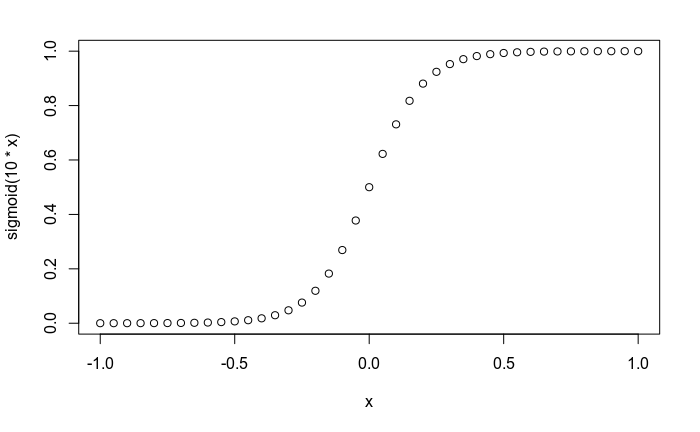

```r
e=exp(1)
sigmoid <- function(x){ 1 /(1 + e^-x) }

output_function <- function(input=input_layer,bias=synaptic_weights){ sigmoid(input %*% bias) }
x <- seq(-1.0,1.0,0.05)
plot(x, sigmoid(10*x))
```

##### Feedback

During training, the output it compared to the training value. Error is the difference between the training valued and the actual value. An adjust is made to the weights based on the error value and the derivative if the output function

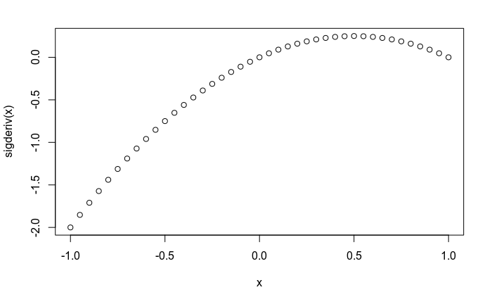

```r
sigderiv <- function(sig){ sig * (1 - sig)}
plot(x,sigderiv(x))
```

```r
rm(x)
```

##### Training

Now the training begins:

The steps above are repeated until we see that the actual output is pretty much these same as the training output.

```r
train <- function(){
  for(iterator in 1:20000){
    # net_inputs = input_layer x synaptic_weights. Sigmoid is our transfer function
    outputs <- sigmoid(input_layer %*% synaptic_weights) #output_function(input_layer)
    errors  <- training_outputs - outputs
    adjustments <- errors * sigderiv(outputs)
    synaptic_weights <- synaptic_weights + t(input_layer) %*% adjustments
  }
  colnames(outputs) <- c("output")
  print(outputs)
  print(synaptic_weights)
  #assign("synaptic_weights", synaptic_weights, envir = .GlobalEnv)
  return(synaptic_weights)
}
#trained_weights <- train()
system.time(trained_weights<-train())
```

```
             output
sample1 0.006796280
sample2 0.994456179
sample3 0.995485384
sample4 0.005535852
       weights
2^0 10.3805215
2^1 -0.2063981
2^2 -4.9845859
   user  system elapsed
  0.159   0.002   0.160
```

##### Weights After Training

The real purpose of training is to produce this weighs that are now useful for solving novel inputs

```r
print(trained_weights)
```

```
       weights
2^0 10.3805215
2^1 -0.2063981
2^2 -4.9845859
```

##### Output of trained neuron for novel input

```r
print(new_input <- matrix(c( 1, 0, 0 ), 1,3,TRUE,dimnames = list(c("input"),c("x4","x2","x1"))))
```

```
      x4 x2 x1
input  1  0  0
```

```r
new_output <- output_function(new_input, trained_weights)
dimnames(new_output) <- list(c("1 value"),c("output"))
print(new_output)
```

```
          output
1 value 0.999969
```

### Ann the Two-Layer Perceptron

[^1]: “Perc”eptron
[^2]: ANN